# Using Monte Carlo Simulations to Create Estimations for Pulls Needed to Achieve Goals

This project will take known probabilities and apply known ceilings and assumed floors as constraints to achieve certain goals.  
The goal of this project is to allow a user to establish an estimated number of pulls to reach a target from any given start point.

```python
import numpy as np
import pandas as pd
import matplotlib.pyplot as plt

from jupyterthemes import jtplot
jtplot.style(theme='onedork', context='notebook', ticks=True, grid=False, figsize=(8,6))
```

# The Setup

There are two sets of probabilities. One set of probabilities corresponds to MR and UR+ shards while the other set corresponds to the UR and SSR+ shards.  
There are two sets of pities and floors. One set corresponds to MR, UR+ and UR shards while the other set corresponds to SSR+ shards.  
The number of shards needed for the initial awakens differs for each rarity. The number of shards needed to awaken each star are constant for MR, UR+ and UR but differ for SSR+. As such, the targets for each awakening differs for all of them.

```python
# Define probabilities
mr_shard_probs = {
    0: 0.66225,
    1: 0.23841,  # Probability of winning 1 shard
    2: 0.07285,  # Probability of winning 2 shards
    5: 0.02649   # Probability of winning 5 shards
}
urp_shard_probs = {
    0: 0.66225,
    1: 0.23841,  # Probability of winning 1 shard
    2: 0.07285,  # Probability of winning 2 shards
    5: 0.02649   # Probability of winning 5 shards
}
ur_shard_probs = {
    0: 0.745,
    1: 0.180,
    2: 0.055,
    5: 0.020
}
ssrp_shard_probs = {
    0: 0.745,
    1: 0.180,
    2: 0.055,
    5: 0.020
}

# Number of monte carlo simulations
num_simulations = 20000

# Desired shard counts
mr_desired_shards = [70, 90, 120, 160, 210, 270]
urp_desired_shards = [65, 85, 115, 155, 205, 265]
ur_desired_shards = [60, 80, 110, 150, 200, 260]
ssrp_desired_shards = [55, 65, 85, 115, 155, 205]

# pity and floor parameters
main_pities = [6, 16, 65]
main_floors = [6, 15, 58]
ssrp_pities = [7, 20, 55]
ssrp_floors = [7, 19, 48]

# colormaps
mr_cmap = plt.get_cmap('turbo')
urp_cmap = plt.get_cmap('spring')
ur_cmap = plt.get_cmap('cool_r')
ssrp_cmap = plt.get_cmap('Reds')

# rarity groupings [0-probs, 1-targets, 2-pities, 3-floors, 4-cmap]
mr = [mr_shard_probs, mr_desired_shards, main_pities, main_floors]
urp = [urp_shard_probs, urp_desired_shards, main_pities, main_floors]
ur = [ur_shard_probs, ur_desired_shards, main_pities, main_floors]
ssrp = [ssrp_shard_probs, ssrp_desired_shards, ssrp_pities, ssrp_floors]

# column names
star_ratings = ['0 star', '1 star', '2 star', '3 star', '4 star', '5 star']
```

# The Execution

A function is created that will run a number of simulations based on the parameters relevant to a given rarity. The results of those simulations are stored in a pandas dataframe.  
Another function is created to plot the results of those simulations with their respective measures of central tendency.

```python
def monte(rarity):
    '''
    Returns a dataframe of the monte carlo simulations with columns for each star
    and rows for each run describing the number of pulls to awaken each star.
    '''
    df = pd.DataFrame(columns = star_ratings)

    for iteration in range(num_simulations):
        # initialize run
        shard_probs = rarity[0]
        desired_shards = rarity[1]
        pities = rarity[2]
        floors = rarity[3]
        pulls = 0
        total_shards = 0
        shard_targets = desired_shards.copy()
        this_run = [] # [iteration, 70, 90, 120, 160, 210, 270]
        cur_pity = [0, 0, 0]

        while total_shards < desired_shards[-1]:
            pulls += 1
            cur_pity = [x + 1 for x in cur_pity]
            # check pities
            if cur_pity[2] >= pities[2]:
                total_shards += 5
                cur_pity[2] = 0
            elif cur_pity[1] >= pities[1]:
                total_shards += 2
                cur_pity[1] = 0
            elif cur_pity[0] >= pities[0]:
                total_shards += 1
                cur_pity[0] = 0
            # check floors
            else:
                shard_type = np.random.choice(list(shard_probs.keys()), p=list(shard_probs.values()))
                if shard_type == 5:
                    if cur_pity[2] >= floors[2]:
                        total_shards += shard_type
                        cur_pity[2] = 0
                if shard_type == 2:
                    if cur_pity[1] >= floors[1]:
                        total_shards += shard_type
                        cur_pity[1] = 0
                if shard_type == 1:
                    if cur_pity[0] >= floors[0]:
                        total_shards += shard_type
                        cur_pity[0] = 0

            # check targets
            if total_shards >= shard_targets[0]:
                del shard_targets[0]
                this_run.append(pulls)

            if total_shards >= desired_shards[-1]:
                append_dict = {'0 star':[this_run[0]], '1 star':[this_run[1]],'2 star':[this_run[2]],
                               '3 star':[this_run[3]],'4 star':[this_run[4]], '5 star':[this_run[5]]}
                df = pd.concat([df, pd.DataFrame(append_dict)], ignore_index=True)
    return df
```

```python
def results_plot(df, cmap, rarity):
    '''
    Creates a barplot or 6 subplots, 1 for each awaken target. The bars indicate the number of times that
    a certain number of pulls awakened that star target. Each set of plots uses a different colormap.
    '''
    # Create a 2x3 grid of subplots (2 plots wide by 3 plots tall)
    fig, axs = plt.subplots(3, 2, figsize=(20, 15))

    for i, star in enumerate(star_ratings):
        color_len = df[star].nunique()
        row, col = divmod(i, 2)  # Calculate row and column indices
        value_counts = df[star].value_counts().sort_index()
        axs[row, col].bar(value_counts.index, value_counts.values, color=cmap(np.linspace(0.2, 0.8, color_len)))
        axs[row, col].set_xlabel('Number of Pulls')
        axs[row, col].set_ylabel(f'Number of Occurrences')
        axs[row, col].set_title(f'Frequency of Pulls for {rarity} {star} at {num_simulations:,} Runs')
        xaxis = [x for x in df[star].unique()]
        # Set x-axis ticks to match value_counts
        axs[row, col].set_xticks(xaxis)

        star_df = pd.DataFrame({'pulls': value_counts.index, 'count': value_counts.values})
        star_df['weighted'] = star_df['count'] * star_df['pulls']
        avg = star_df['weighted'].sum() / num_simulations
        count_max = star_df['count'].max()
        mode = star_df.loc[star_df['count'] == count_max, 'pulls'].iloc[0]
        low = star_df.pulls.min()
        high = star_df.pulls.max()

        # Add text annotations (aligned to the left)
        axs[row, col].text(0.01, 0.99, f"Min: {low:.2f}", transform=axs[row, col].transAxes, ha='left', va='top')
        axs[row, col].text(0.01, 0.9, f"Max: {high:.2f}", transform=axs[row, col].transAxes, ha='left', va='top')
        axs[row, col].text(0.01, 0.8, f"Mode: {mode:.2f}", transform=axs[row, col].transAxes, ha='left', va='top')
        axs[row, col].text(0.01, 0.7, f"Mean: {avg:.2f}", transform=axs[row, col].transAxes, ha='left', va='top')

    plt.tight_layout()
    plt.show()
```

```python
def results_df(ssrp_df, ur_df, urp_df, mr_df):
    df = pd.DataFrame(columns = ['rarity_star', 'min', 'max', 'mode', 'mean'])
    dfs = [ssrp_df, ur_df, urp_df, mr_df]
    rarities = ['SSR+', 'UR', 'UR+', 'MR']
    i = 0
    while i < len(rarities):
        data = dfs[i]
        rarity = rarities[i]


        for star in enumerate(star_ratings):
            this_col = star[1]
            value_counts = data[this_col].value_counts().sort_index()
            star_df = pd.DataFrame({'pulls': value_counts.index, 'count': value_counts.values})
            star_df['weighted'] = star_df['count'] * star_df['pulls']
            rarity_star = rarities[i] + str(star[0])
            this_min = star_df.pulls.min()
            this_max = star_df.pulls.max()
            count_max = star_df['count'].max()
            this_mode = star_df.loc[star_df['count'] == count_max, 'pulls'].iloc[0]
            this_mean = star_df['weighted'].sum() / num_simulations

            append_dict = {'rarity_star': [rarity_star],
                           'min': [this_min],
                           'max': [this_max],
                           'mode': [this_mode],
                           'mean': [this_mean]}
            df = pd.concat([df, pd.DataFrame(append_dict)], ignore_index=True)
        i += 1

    return df
```

# The Results

The monte carlo simulations are run for each of the rarities and then plotted.  
Afterwards, a table will be created for each rarity with the measures of central tendency as the columns and the awakens as the rows.  
This table will be useful in a SQL database with the purpose of allowing a user to query a begin and endpoint for any arrangement  
of awaken statuses to retrieve an approximation of min, max, mode, and mean pulls to achieve their targets.

```python
mr_monte = monte(mr)
urp_monte = monte(urp)
ur_monte = monte(ur)
ssrp_monte = monte(ssrp)
```

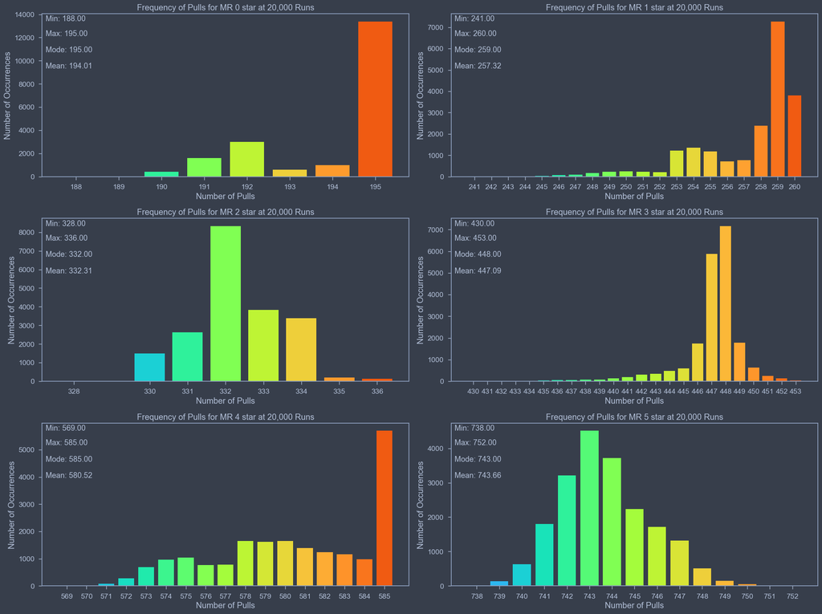

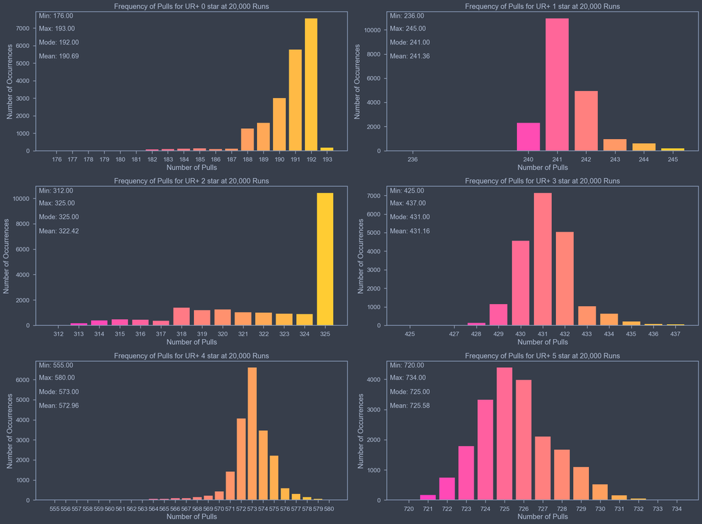

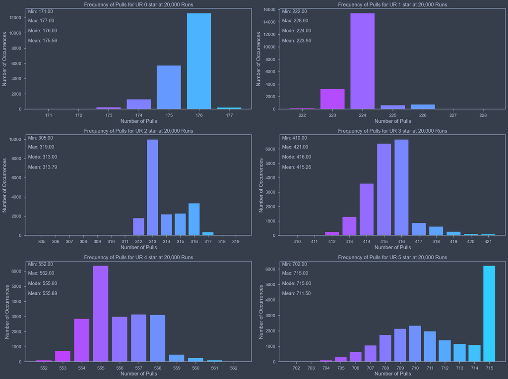

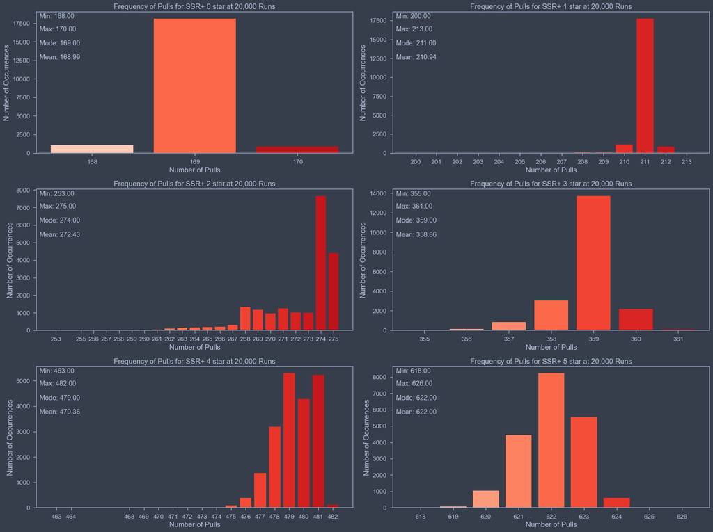

```python
results_plot(mr_monte, mr_cmap, "MR")
results_plot(urp_monte, urp_cmap, "UR+")
results_plot(ur_monte, ur_cmap, "UR")
results_plot(ssrp_monte, ssrp_cmap, "SSR+")
```

```python
results = results_df(ssrp_monte, ur_monte, urp_monte, mr_monte)
results
```

|  | rarity_star | min | max | mode | mean |
| --- | --- | --- | --- | --- | --- |
| 0 | SSR+0 | 168 | 170 | 169 | 168.98990 |
| 1 | SSR+1 | 200 | 213 | 211 | 210.94140 |
| 2 | SSR+2 | 253 | 275 | 274 | 272.43380 |
| 3 | SSR+3 | 355 | 361 | 359 | 358.85535 |
| 4 | SSR+4 | 463 | 482 | 479 | 479.36475 |
| 5 | SSR+5 | 618 | 626 | 622 | 622.00445 |
| 6 | UR0 | 171 | 177 | 176 | 175.56165 |
| 7 | UR1 | 222 | 228 | 224 | 223.93745 |
| 8 | UR2 | 305 | 319 | 313 | 313.79490 |
| 9 | UR3 | 410 | 421 | 416 | 415.25665 |
| 10 | UR4 | 552 | 562 | 555 | 555.88055 |
| 11 | UR5 | 702 | 715 | 715 | 711.50330 |
| 12 | UR+0 | 176 | 193 | 192 | 190.68705 |
| 13 | UR+1 | 236 | 245 | 241 | 241.36105 |
| 14 | UR+2 | 312 | 325 | 325 | 322.42440 |
| 15 | UR+3 | 425 | 437 | 431 | 431.16345 |
| 16 | UR+4 | 555 | 580 | 573 | 572.95625 |
| 17 | UR+5 | 720 | 734 | 725 | 725.58005 |
| 18 | MR0 | 188 | 195 | 195 | 194.01050 |
| 19 | MR1 | 241 | 260 | 259 | 257.31790 |
| 20 | MR2 | 328 | 336 | 332 | 332.30730 |
| 21 | MR3 | 430 | 453 | 448 | 447.08735 |
| 22 | MR4 | 569 | 585 | 585 | 580.52335 |
| 23 | MR5 | 738 | 752 | 743 | 743.66180 |

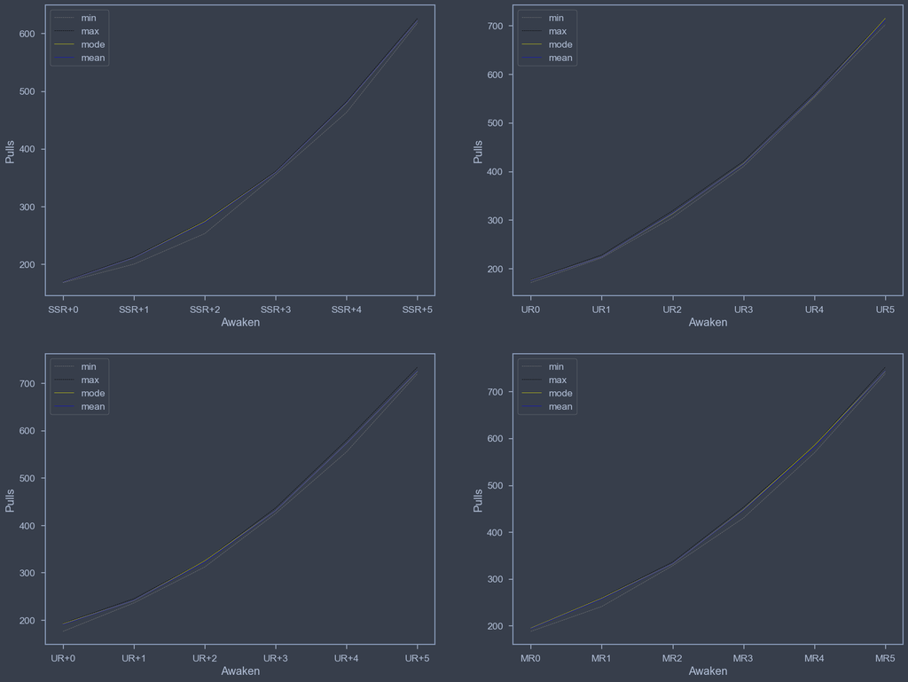

```python
fix, axs = plt.subplots(2, 2, figsize=(20,15))

for i, ax in enumerate(axs.flat):
    start_row = i * 6
    end_row = start_row +6
    subset_df = results.iloc[start_row:end_row]
    ax.plot(subset_df['rarity_star'], subset_df['min'], label='min', alpha=1, color='gray', linewidth=0.5, linestyle='--')
    ax.plot(subset_df['rarity_star'], subset_df['max'], label='max', alpha=1, color='black', linewidth=0.5, linestyle='--')
    ax.plot(subset_df['rarity_star'], subset_df['mode'], label='mode', alpha=0.8, color='yellow', linewidth=0.5)
    ax.plot(subset_df['rarity_star'], subset_df['mean'], label='mean', alpha=0.8, color='blue', linewidth=0.5)
    ax.set_xlabel('Awaken')
    ax.set_ylabel('Pulls')
    ax.legend()
```

# Save Results

Output the results to a CSV to allow entry into a database.

```python
results.to_csv('monte_carlo_pulls.csv', index=True)
print(f"Data saved to CSV")
```

```
Data saved to CSV
```